# Upper San Joaquin Habitat

## Background

This document describes the process of adding instream juvenile and fry rearing, spawning, and floodplain rearing to the Upper San Joaquin reach of the [SpringRunDSM](https://github.com/Reorienting-to-Recovery/springRunDSM) (from Merced River confluence to Friant Dam). The Lower San Joaquin reach is 45.7 miles long while the Upper San Joaquin Reach is 153 miles in length. There is only one San Joaquin reach in the 2018/2019 BiOp CalSim and therefore habitat data for Lower and Upper San Joaquin River use flow data from CalSim node C630.

*Depth and velocity suitability criteria for the Yuba River spawning and rearing for Chinook salmon, with a suitability index greater than 10% for spawning and greater than 30% for rearing*

| River | Species | Race | Life Stage | Suitability Metric | Value | Unit | Suitability Index |
| --- | --- | --- | --- | --- | --- | --- | --- |
| Yuba | Chinook | Spring | Spawning | Depth | 0.5000010 | Feet | 0.1709662 |
| Yuba | Chinook | Spring | Spawning | Depth | 0.6000012 | Feet | 0.2242333 |
| Yuba | Chinook | Spring | Spawning | Depth | 0.7000014 | Feet | 0.2865339 |
| Yuba | Chinook | Spring | Spawning | Depth | 0.8000016 | Feet | 0.3569352 |
| Yuba | Chinook | Spring | Spawning | Depth | 0.9000018 | Feet | 0.4337802 |
| Yuba | Chinook | Spring | Spawning | Depth | 1.0000020 | Feet | 0.5147832 |
| Yuba | Chinook | Spring | Spawning | Depth | 1.1000022 | Feet | 0.5972113 |
| Yuba | Chinook | Spring | Spawning | Depth | 1.2000024 | Feet | 0.6781174 |
| Yuba | Chinook | Spring | Spawning | Depth | 1.3000026 | Feet | 0.7545803 |
| Yuba | Chinook | Spring | Spawning | Depth | 1.4000028 | Feet | 0.8239125 |

[output cut: 118 more lines]

## Instream Rearing Habitat

We ran a [1D Hec Ras model](https://www.restoresjr.net/?wpfb_dl=1962) for flows ranging from 100 to 4500 CFS at all nodes of the bypasses (Chowchilla, Eastside, and Mariposa) and reaches 1, 1A, 2A, and 5. We applied suitability criteria based on depth and velocity to all nodes and flows to identify suitable areas for in-channel and floodplain rearing for the Upper San Joaquin River between Merced River and Friant Dam.

We applied suitability criteria to the outputs of the Hec Ras model, considering suitable depth and velocity for instream juvenile and fry rearing. We used the Yuba River depth and velocity criteria as a proxy for the Upper San Joaquin River, utilizing data provided by Mark Gard from the California Department of Fish and Wildlife (see table below). For instream rearing, we used depth and velocity values for a suitability of 0.3 or greater (30% and greater of in channel area is suitable for rearing).

**Future Improvements** Reaches used for instream and floodplain rearing can be updated to include mainstem (2B - 4B2) reaches. This dataset assumes flow primarily through the bypasses.

**Data Source:**

- Reclamation (2012). Hydraulic Studies for Fish Habitat Analysis, Technical Report No. SRH-2012-15. Prepared for San Joaquin River Restoration Project, Mid-Pacific Region, US Bureau of Reclamation, Technical Service Center, Denver, CO.
- Mark Gard - USFWS (2010a)

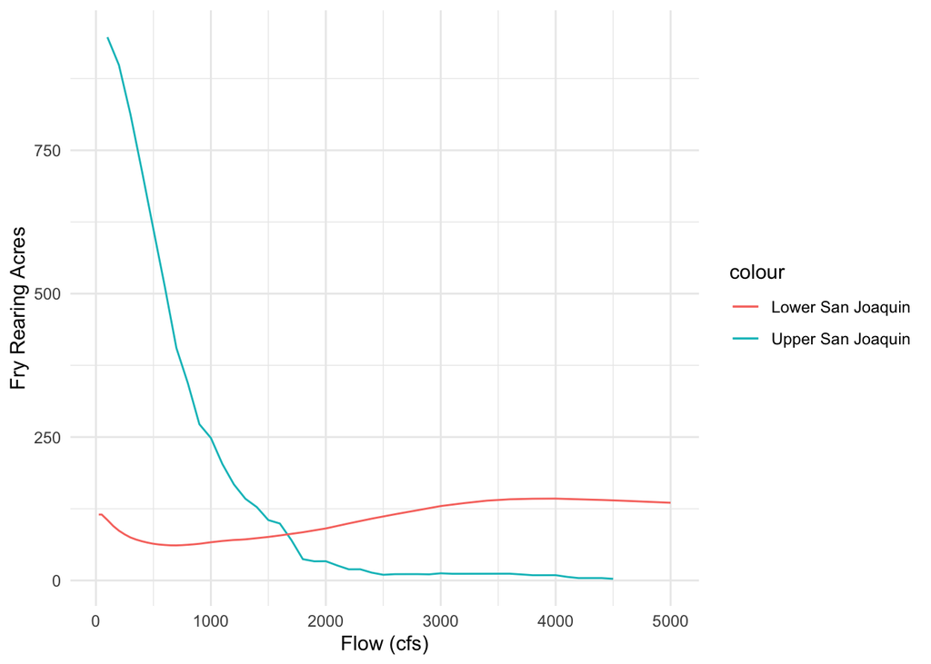

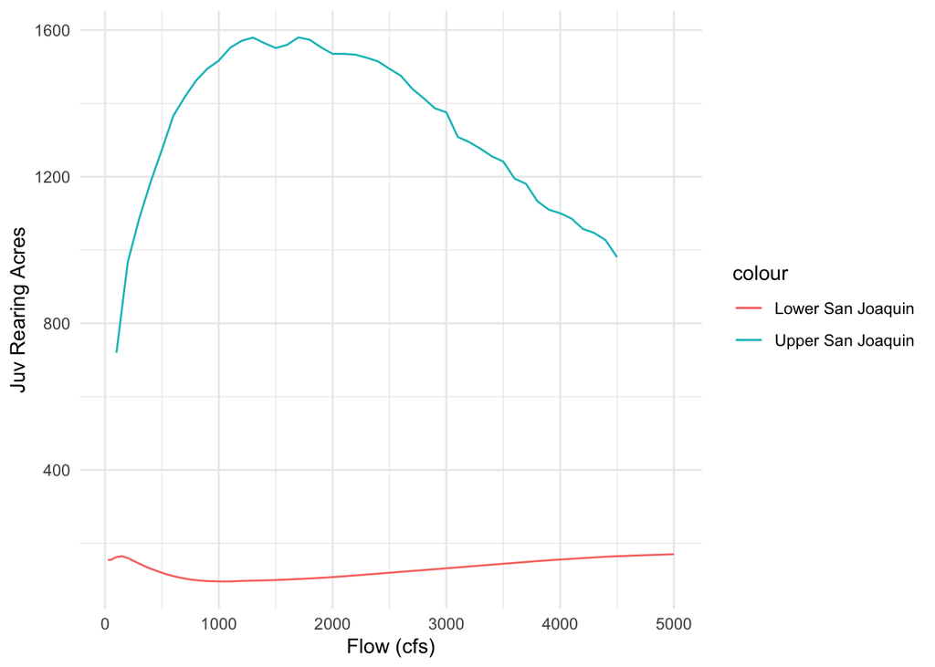

# Floodplain Rearing

We calculate floodplain rearing based on the surface area extending beyond the channel in the Hec Ras 1D model outputs, covering flows ranging from 100 to 4500 cfs. The suitability is derived from Figure 39 of the Basso/La Grange Reach Floodplain and Spawning Habitat Restoration Project - 30% Basis of Design Report, which presents the HSI for depth and velocity for juvenile Chinook. We utilized the CBEC (2020) curve for floodplain rearing, employing a suitability index of 0.1 and above (indicating that 10% or more of the floodplain area is deemed suitable for floodplain rearing).

**Data Sources:**

- cbec. 2020. Lower Yuba River Temporal Habitat Evaluation, Yuba River Flow Effects Modeling Report, Lower Yuba River, California. Prepared for Trout Unlimited and U.S. Fish and Wildlife Service. July 2020. cbec project #: 19-1029.
- Reclamation (2012). Hydraulic Studies for Fish Habitat Analysis, Technical Report No. SRH-2012-15. Prepared for San Joaquin River Restoration Project, Mid-Pacific Region, US Bureau of Reclamation, Technical Service Center, Denver, CO.

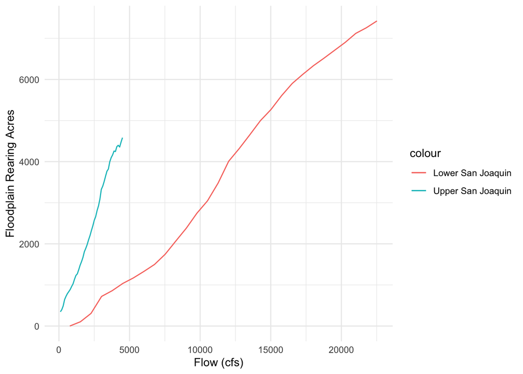

Header Descriptions: flow_cfs = flow in cubic feet per second, SR_floodplain_acres = Spring Run Chinook floodplain acres, watershed = section of stream modeled for CVPIA SDM

| flow_cfs | SR_floodplain_acres |
| --- | --- |
| 100 | 346.24 |
| 200 | 397.82 |
| 300 | 488.67 |
| 400 | 643.21 |
| 500 | 723.32 |

*… with 40 more rows*

## Spawning Habitat

We ran the 1D Hec Ras model for flows ranging from 100 to 4500 CFS at reaches 1A and 1B for spawning. We applied suitability criteria based on depth and velocity to all nodes and flows, determining a suitable area for spawning in the Upper San Joaquin River between Merced River and Friant Dam.

We applied suitability criteria to the outputs of the Hec Ras model, assessing suitable depth and velocity for spawning. Utilizing the Yuba River depth and velocity criteria as a proxy for the Upper San Joaquin River, with data provided by Mark Gard from the California Department of Fish and Wildlife, we identified areas suitable for spawning. For spawning purposes, we considered depth and velocity values, aiming for a suitability of 0.1 or greater (where 10% or more of the in-channel area is deemed suitable for spawning).

**Data Source:**

- Reclamation (2012). Hydraulic Studies for Fish Habitat Analysis, Technical Report No. SRH-2012-15. Prepared for San Joaquin River Restoration Project, Mid-Pacific Region, US Bureau of Reclamation, Technical Service Center, Denver, CO.
- Mark Gard - USFWS (2010a)

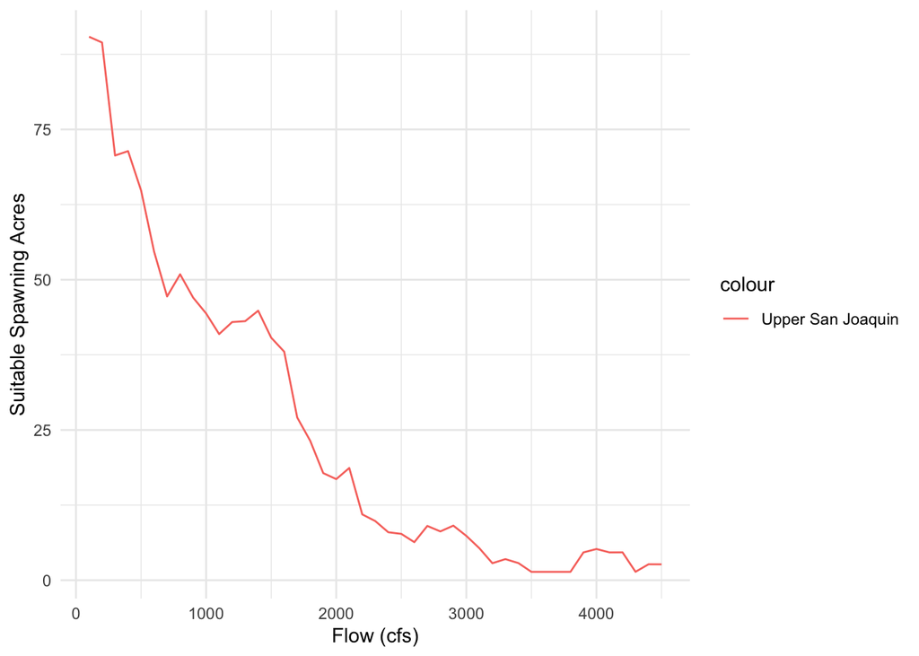

Header Descriptions: flow_cfs = flow in cubic feet per second, SR_spawn_acres = Spring Run Chinook Spawning Acres, SR_fry_acres = Spring Run Chinook Fry Acres, SR_juv_acres = Spring Run Chinook Juvenile Acres, watershed = section of stream modeled for CVPIA SDM

| watershed | flow_cfs | SR_fry_acres | SR_juv_acres | SR_fry_sqm | SR_juv_sqm | SR_spawn_acres | SR_spawn_sqm |
| --- | --- | --- | --- | --- | --- | --- | --- |
| San Joaquin River | 100 | 947.11 | 719.79 | 3832824 | 2912891 | 90.42 | 365917.3 |
| San Joaquin River | 200 | 898.55 | 967.63 | 3636308 | 3915866 | 89.46 | 362032.3 |
| San Joaquin River | 300 | 812.93 | 1085.70 | 3289816 | 4393679 | 70.66 | 285951.3 |
| San Joaquin River | 400 | 714.00 | 1185.08 | 2889460 | 4795856 | 71.39 | 288905.5 |
| San Joaquin River | 500 | 612.27 | 1273.91 | 2477773 | 5155339 | 64.85 | 262439.0 |

*… with 40 more rows*

# Plots

## Spawning Plot

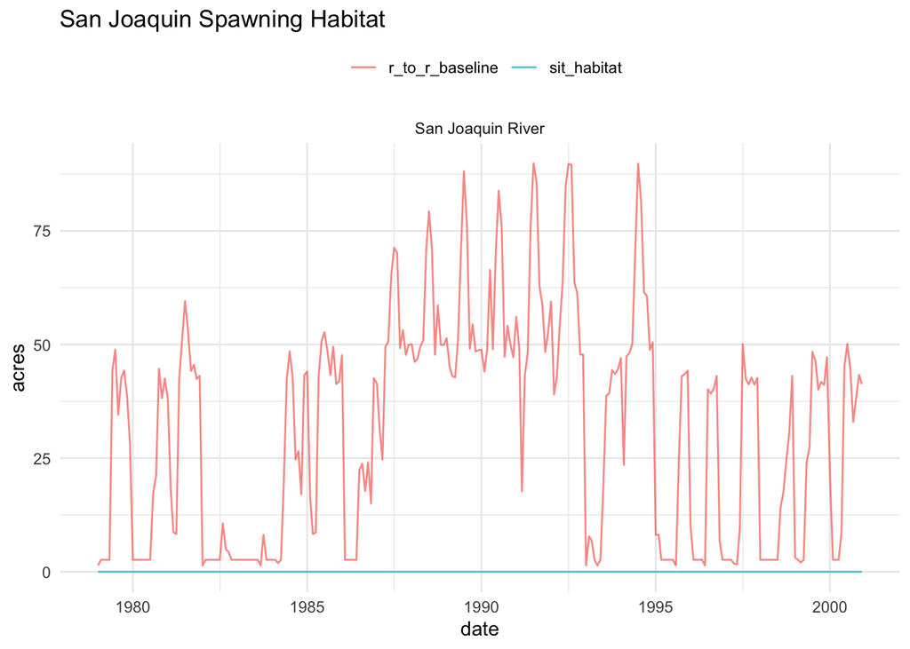

## Floodplain Rearing Plot

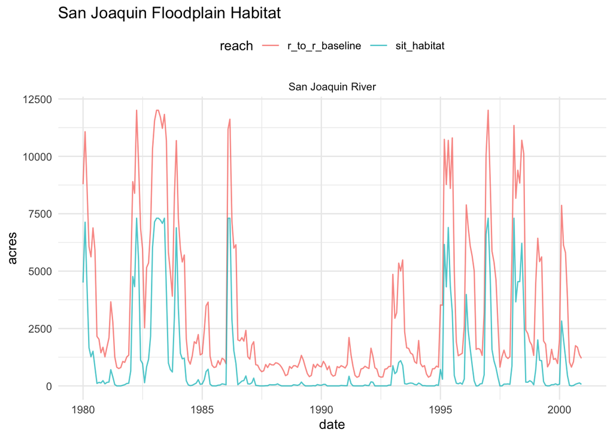

## Instream Rearing - Juveniles:

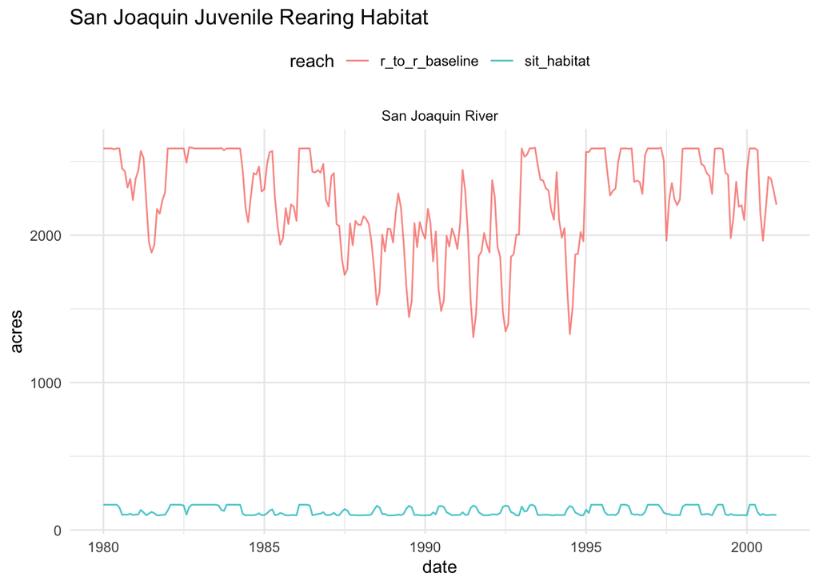

## Instream Rearing - Fry

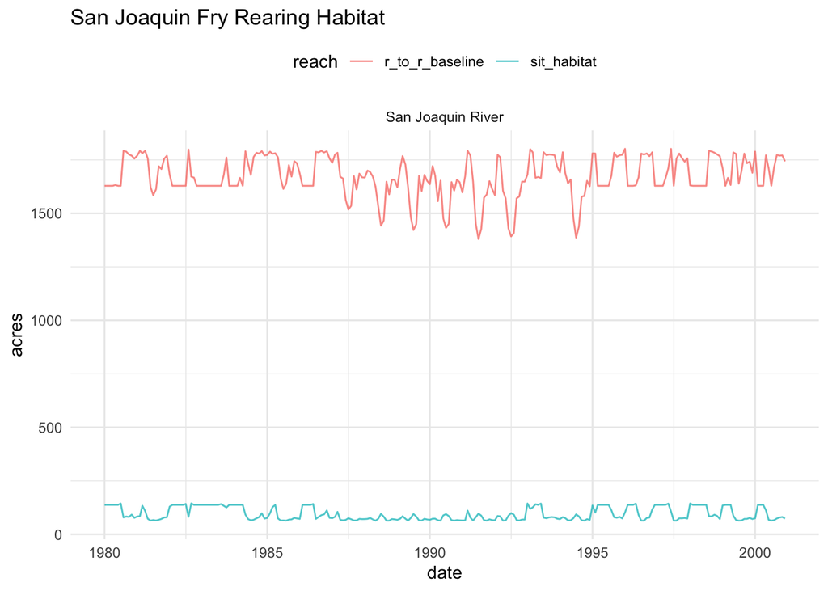